# Group 10 Draft

# Introduction to clustering analysis

[The hierarchical analysis][https://en.wikipedia.org/wiki/Hierarchical_clustering#Divisive_clustering]

Divisive hierachical algorithms are built top-down: starting with the whole sample in a unique cluster they split this cluster into two subclusters which are, in turn, divided into subclusters and so on. At each step the two new clusters make up a so-called bipartition of the former. It is well known (Edwards and Cavalli-Sforza 1965) that there are 2n - 1 – 1 ways of splitting a set of n objects into two subsets.

[Euclidean distance][https://en.wikipedia.org/wiki/Euclidean_distance]

$$||a-b||_2 = \sqrt{\sum_i (a_i-b_i)^2}$$

# Dataset used here

## Source:

[Black Friday, Kaggle Reference][https://www.kaggle.com/mehdidag/black-friday]

The dataset here is a sample of the transactions made in a retail store. The store wants to know better the customer purchase behaviour against different products.

Dataset of 550 000 observations about the black Friday in a retail store, it contains different kinds of variables either numerical or categorical.  
## Including Plots

## Variables inside:

User_ID: User ID Product_ID: Product ID Gender: Sex of User  
Age: Age in bins  
Occupation: Occupation  
City_Category: Category of the City: A,B,C  
Stay_In_Current_City_Years: Number of years stay in current city  
Marital_Status: Marital Status  
Product_Category_1: Product Category  
Product_Category_2: Product may belongs to other category also  
Product_Category_3: Product may belongs to other category also  
Purchase: Purchase amount in dollars

## Goal:

By saying predict customer preference, we expect to find informative characteristics of each group after clustering. we plan to use a few of the attributes in the data only for segmentation and the remaining only to profile the clusters. These profiling attributes (e.g. demographic and behavioral data) would help us better understand patterns of different customer groups. Meantime, we expect to check robustness of our hierarchical clustering models by comparing similarity between these profiling variables.

# Running divisive clustering analysis in STATA

Similar to R and Python, we need to first import the dataset into STATA. We use the “import delimited” command.  
import delimited “/Users/meng/Downloads/BlackFriday.csv”

We only use information in “product_category_1” for clustering analysi considered too many missing values in another two categories. In our clustering model, we use customer preference, defined as proporation of expense in each product category, to help identify market segments and use some of the remaining geo-demographic attribututes to profile the clusters. Therefore, we later reshaped the dataset to the wide format and obtain 18 different variables.  
reshape wide all_purchase, i(user_id) j(product_category_1)

Later, to provide a first understanding of the dataset, we draw a histogram graph of all pairwise distance for eucliean distance. The “mountain an valleys” patterns in the graph indicates there indeed multiple fragments in the dataset.  
hist distance, freq title(“histogram of pairwise distances”)

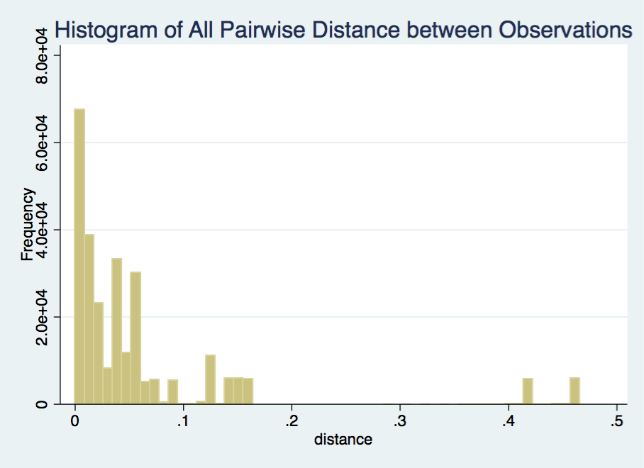

Unlike R, there is no relevant command to compute divisive hierarchical clustering analysis. We thus write our own programming command “Diana” with reference to Kaufman, L. and Pousseeuw, P.J. (1999). The alogrithm is fully describe in Chapter 6. Even though it has reduced the computation cost quite a lot, it still takes much time for the loop compared with agglomerative hierarchical clustering method. For simplicity, we at first look at the 4-segments solution and the segmentation result is shown as following for the first 10 consumers in the dataset.  
**list group in 1/10

| user_id | cluster_group |
| --- | --- |
| 1000001 | 1 |
| 1000002 | 1 |
| 1000003 | 1 |
| 1000004 | 1 |
| 1000005 | 1 |
| 1000006 | 1 |
| 1000007 | 1 |
| 1000008 | 1 |
| 1000009 | 1 |
| 1000010 | 1 |

We also plot a line chart to compare difference between groups:

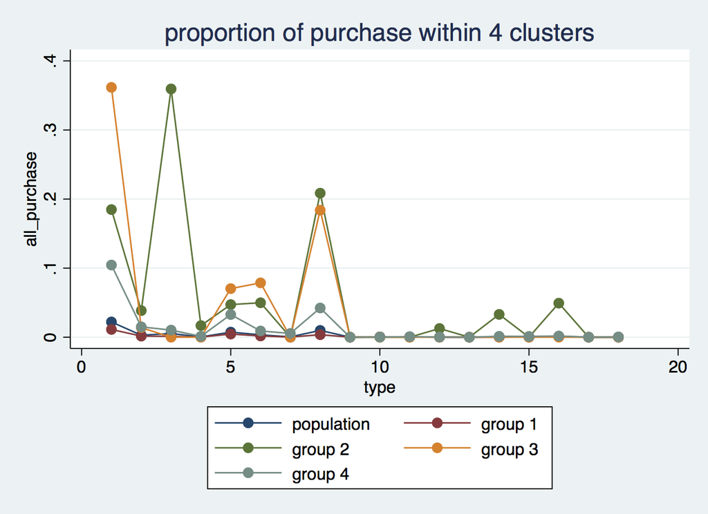

Combined demographic features, we use the following plots to help detect divergence among these four clusters:

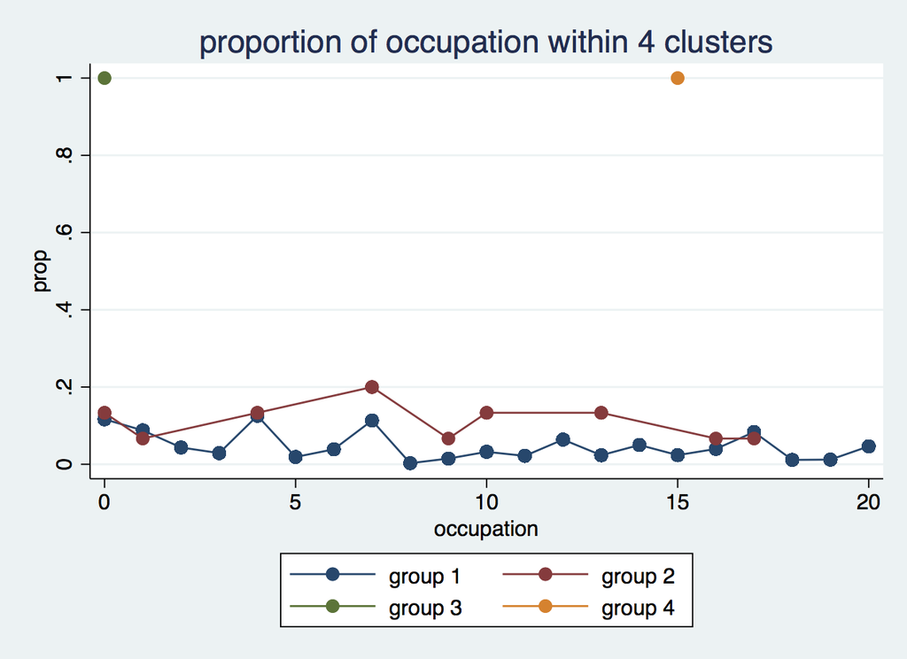

# Running divisive clustering analysis in Python

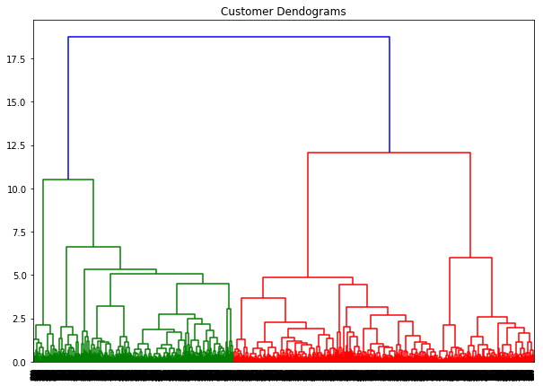

# Running divisive clustering analysis in R

```r
# Load all the libraries we need for our analysis:
library(sqldf)
library(cluster)
library(ggplot2)
library(tidyr)
library(dplyr)
# We need to load data into R by using read.csv since it’s in csv format.
data=read.csv("https://raw.githubusercontent.com/Anranmg/project506/master/BlackFriday.csv",header=TRUE, sep=',')

# Because product category2 and category3 are products belong to other catagory, it recalculate same product, we drop these two category.
# By manipulating data, we get a new dataset with user_id and 18 category1 ratios for each user.
data=data %>%
  select(-Product_ID,-Product_Category_2,-Product_Category_3)%>%
  group_by(User_ID)%>%
  mutate(total=sum(Purchase))%>%
  group_by(User_ID,Product_Category_1)%>%
  summarise(Purchase=sum(Purchase),total=mean(total))%>%
  mutate(Purchase=Purchase/total)%>%
  spread(Product_Category_1,Purchase)%>%
  replace(.,is.na(.),0)%>%
  select(-total)

# Since the dataset is so large, it will takes more than 10 mins to run, we choose first 100 data to just show
# one result.
data = head(data, n = 100)
```

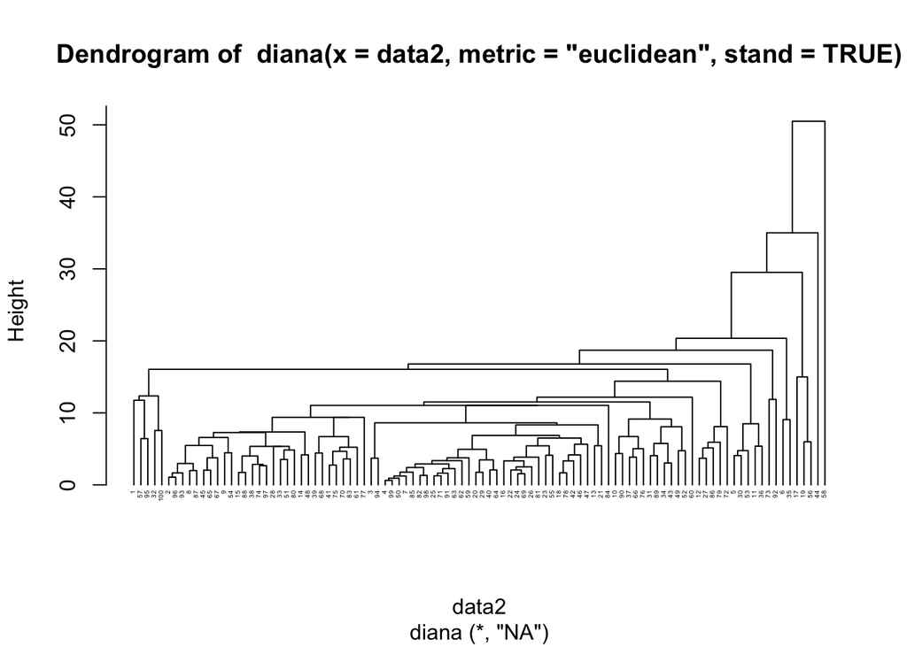

```r
# Standardization data
data2 = data[2:19]
data1 = scale(data[2:19])

# Using diana cluster to cluster, and get the dendrogram of diana.
# And we use euclidean method to calculate distance.
sol = diana(data2, metric = "euclidean", stand = TRUE)
pltree(sol, cex = 0.3, hang = -1)
```

```r
# Just for test, we choose k=4 to cluster data into 4 groups.
cluster_id = cutree(as.hclust(sol), k = 4)

# Check the number of each cluster
table(cluster_id)
```

```
## cluster_id
##  1  2  3  4
## 95  3  1  1
```

```r
data_cluster = data.frame(cluster_id)
tmp=cbind(cluster_id=data_cluster$cluster_id,data)
data_all=sqldf('select a.*,b.cluster_id from data as a left join tmp as b on a.User_ID=b.User_ID')

# Select cluster number to generate barplot of category ratio in cluster 1.
cluster_data=sqldf('select a.* from data_all as a where a.cluster_id = 1')
# Summary cluster data.
summary(cluster_data)
```

```
##     User_ID            1                2                 3
##  Min.   :1e+06   Min.   :0.0000   Min.   :0.00000   Min.   :0.00000
##  1st Qu.:1e+06   1st Qu.:0.2095   1st Qu.:0.00000   1st Qu.:0.00000
##  Median :1e+06   Median :0.3631   Median :0.03190   Median :0.02529
##  Mean   :1e+06   Mean   :0.4009   Mean   :0.04601   Mean   :0.05236
##  3rd Qu.:1e+06   3rd Qu.:0.5175   3rd Qu.:0.06819   3rd Qu.:0.08523
##  Max.   :1e+06   Max.   :1.0000   Max.   :0.30370   Max.   :0.35942
##        4                  5                 6                 7
##  Min.   :0.000000   Min.   :0.00000   Min.   :0.00000   Min.   :0.00000
##  1st Qu.:0.000000   1st Qu.:0.09598   1st Qu.:0.00000   1st Qu.:0.00000
##  Median :0.000000   Median :0.16379   Median :0.03969   Median :0.00000
##  Mean   :0.006017   Mean   :0.19046   Mean   :0.06187   Mean   :0.00483
##  3rd Qu.:0.008532   3rd Qu.:0.23886   3rd Qu.:0.10770   3rd Qu.:0.00000
##  Max.   :0.076112   Max.   :0.70237   Max.   :0.43900   Max.   :0.09320
##        8                 9                   10
##  Min.   :0.00000   Min.   :0.000e+00   Min.   :0.000000
##  1st Qu.:0.06622   1st Qu.:0.000e+00   1st Qu.:0.000000
##  Median :0.14665   Median :0.000e+00   Median :0.000000
##  Mean   :0.16111   Mean   :4.033e-05   Mean   :0.014307
##  3rd Qu.:0.21631   3rd Qu.:0.000e+00   3rd Qu.:0.003407
##  Max.   :0.64047   Max.   :3.831e-03   Max.   :0.186480
##        11                 12                 13
##  Min.   :0.000000   Min.   :0.000000   Min.   :0.0000000
##  1st Qu.:0.000000   1st Qu.:0.000000   1st Qu.:0.0000000
##  Median :0.002108   Median :0.000000   Median :0.0000000
##  Mean   :0.014551   Mean   :0.001168   Mean   :0.0004887
##  3rd Qu.:0.013021   3rd Qu.:0.000000   3rd Qu.:0.0003802
##  Max.   :0.273312   Max.   :0.012576   Max.   :0.0044587
##        14                 15                16
##  Min.   :0.000000   Min.   :0.00000   Min.   :0.000000
##  1st Qu.:0.000000   1st Qu.:0.00000   1st Qu.:0.000000
##  Median :0.000000   Median :0.00000   Median :0.002424
##  Mean   :0.002961   Mean   :0.01280   Mean   :0.028867
##  3rd Qu.:0.000000   3rd Qu.:0.01584   3rd Qu.:0.042222
##  Max.   :0.050550   Max.   :0.10335   Max.   :0.172889
##        17                  18             cluster_id
##  Min.   :0.0000000   Min.   :0.000000   Min.   :1
##  1st Qu.:0.0000000   1st Qu.:0.000000   1st Qu.:1
##  Median :0.0000000   Median :0.000000   Median :1
##  Mean   :0.0001569   Mean   :0.001071   Mean   :1
##  3rd Qu.:0.0000000   3rd Qu.:0.000000   3rd Qu.:1
##  Max.   :0.0051780   Max.   :0.024201   Max.   :1
```

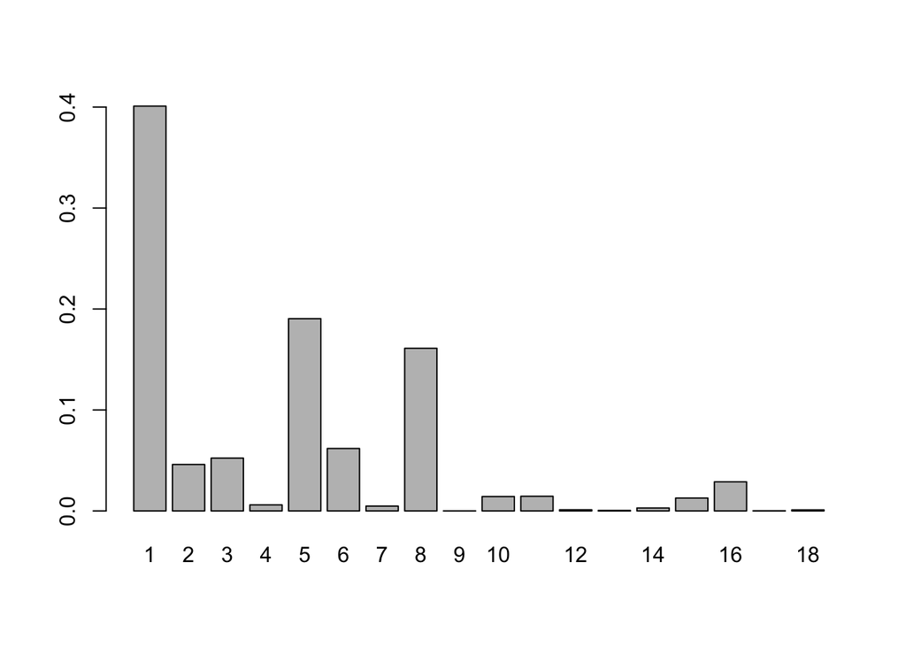

```r
plot_data = colMeans(cluster_data)
barplot(plot_data[2:19])
```

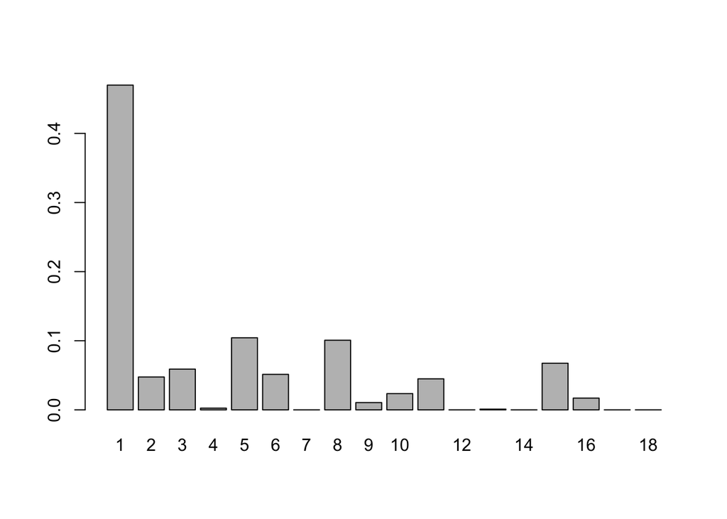

```r
# Select cluster number to generate barplot of category ratio in cluster 2.
cluster_data=sqldf('select a.* from data_all as a where a.cluster_id = 2')
plot_data = colMeans(cluster_data)
barplot(plot_data[2:19])
```

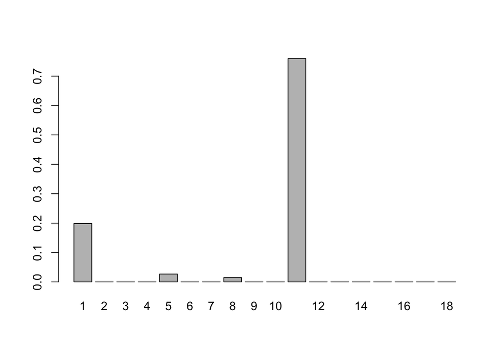

```r
# Select cluster number to generate barplot of category ratio in cluster 3.
cluster_data=sqldf('select a.* from data_all as a where a.cluster_id = 3')
plot_data = colMeans(cluster_data)
barplot(plot_data[2:19])
```

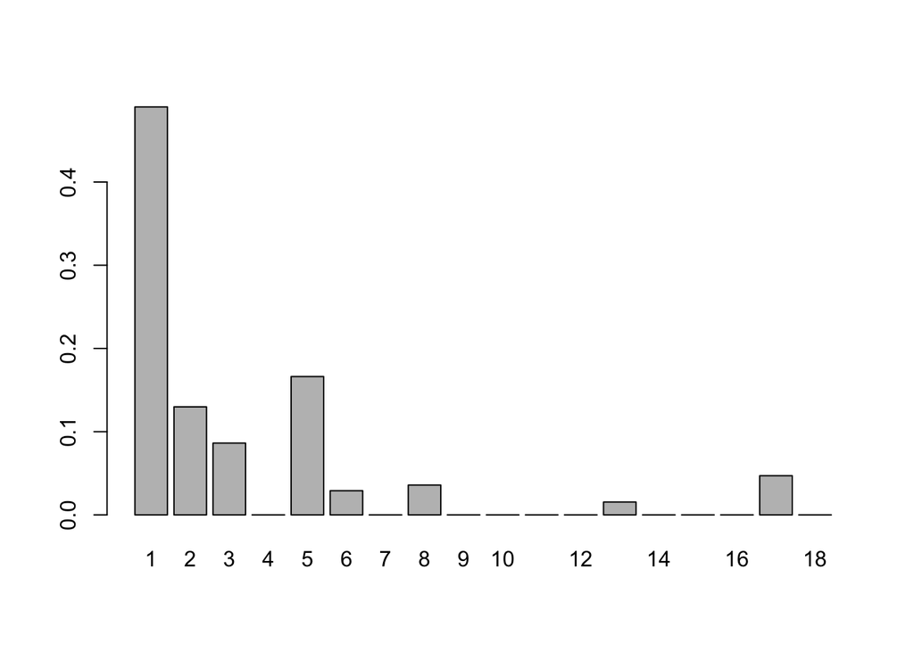

```r
# Select cluster number to generate barplot of category ratio in cluster 4.
cluster_data=sqldf('select a.* from data_all as a where a.cluster_id = 4')
plot_data = colMeans(cluster_data)
barplot(plot_data[2:19])
```

# Outline

2. There are no built-in package or method in Python and Stata that can sufficiently support the divisive algorithm.

Writing functions based on the theory itself is hard to debug and beyond our current understanding.

3. For the final project, we are thinking about dimensionality reduction modeling, plus K-means clustering.

# reference

Finding groups in data: An introduction to cluster analysis

[Cluster Analysis and Segmentation][https://inseaddataanalytics.github.io/INSEADAnalytics/CourseSessions/Sessions45/ClusterAnalysisReading.html#clustering_and_segmentation_using_an_example]